# Implementation of a Binary Logistic Regression Classification model using numpy

Classification is another major task in supervised machine learning, with the objective of predicting the probability of occurence of a particular outcome (the response is usually a categorical variable). Unlike continuous variables, categorical variables are discrete in nature and usually represent an outcome. For example in classification of tumor as malignment or benign, from xray images, the response variable just has 2 values . This is an example of a binary classification problem. The class labels cannot be directly predicted, but a probability of the occurance of a particular label (outcome) can be predicted using an appropriate training algorithm and cost functon. So in the case of the tumor classification, if the predicted probability of the tumor being malignant is 0.7 then using a threshold value (>=0.5), the tumor can be classified as malginant. Threshold values can be set to anything between 0 and 1 but usually 0.5 is used as the class boundary value.

Logistic regression is a very popular method used for binary classification task. The below sections describe how the sigmoid function is used for making predictions in binary classification problems, followed by the definition of cost function used in logistic regression model and the implementation of the training algorithm. Gradient descent is used for the minimizing the cost function in the training process. Metrics like accuracy and confusion matrix are implemented in the module. More metrics can be derived from the confusion matrix (precision, recall etc.) The algorithm is tested on the loan Default dataset from *An Introduction to Statistical Learning with Applications in R* textbook (http://faculty.marshall.usc.edu/gareth-james/ISL/). Comparison is also made with scikit-learn's LogisticRegression function.

```python
import numpy as np
import pandas as pd
import matplotlib.pyplot as plt
from sklearn.model_selection import train_test_split
from sklearn.preprocessing import MinMaxScaler
from sklearn.linear_model import LogisticRegression
import seaborn as sns
%matplotlib inline

def sigmoid(x):
    return 1/(1+np.exp(-x))
```

## Logistic Regression

The logistic regression model revolves around the sigmoid function which is defined as follows, $$ \sigma(Z) = \frac {1}{1+e^{-Z}}$$

Sigmoid varies between 0 and 1, and is plotted below.This property of the sigmoid function makes it a natural choice to predict probabilties of outcomes. The plot also shows the non-linearity of the sigmoid function. This plays a role in the type of the cost function selected in the training process.

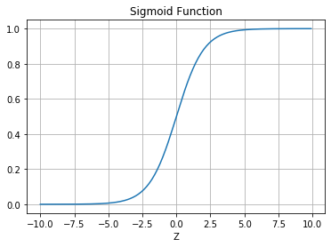

```python
x = np.arange(-10,10,0.1)
plt.figure()
plt.plot(x,sigmoid(x))
plt.title("Sigmoid Function")
plt.xlabel("Z")
plt.grid()
plt.show()
```

The variable Z in the sigmoid function usually represents a summation of terms involving features and coefficients. Generally Z is represented as follows,

$$Z=\beta^{T}X$$

where $\beta$ is the coefficient vector,

$$\beta = \begin {bmatrix} \beta_{0} \\ \beta_{1} \\ . \\ . \\ . \\ \beta_{n} \\ \end{bmatrix}$$

and $X$ is the feature vector $$X=\begin{bmatrix} x_{0} \\ x_{1} \\ . \\ . \\ . \\ x_{n} \\ \end{bmatrix}$$

Here $x_{0} = 1$ and $\beta_{0}$ is the intercept.

## Training algorithm

The values of $\beta$'s which fit the input data the best are determined by an optimization process. A cost function needs to be defined and the values of $\beta$ which minimize the cost function represent the best fit. What this means is the probability predicted by plugging in the $\beta$ coefficients in the sigmoid function results values close to the class labels. In the case of binary classification the class labels are usually 0 and 1. The cross entropy function defined as follows is used as the loss and cost functions in the optimization process.

$$ Loss_i = - {y_i . \log(\sigma(Z_i)) + (1-y_i) . \log(1-\sigma(Z_i))} $$

The main inituition behind using the above loss function is to make sure the value of $sigmoid(Z)$ is close to y which the actual class label of 0 or 1.

1. When y = 1, the 2nd term in the loss function is zero. For the loss function to be as small as possible $sigmoid(Z)$ term need to be close to 1.
2. Similarily when the class label y = 0, the first term in the loss function is zero. For the loss function to be as small as possible $sigmoid(Z)$ value should be close to 0.

Hence the above defintion of the loss function guides the optimization algorithm in the correct directon in both the cases. Cost function which represents the average of the loss function over m training samples is given as below.

$$ Cost J = -\frac{1}{m}\sum_{i=1}^{m}\{y_i . \log(\sigma(Z_i)) + (1-y_i) . \log(1-\sigma(Z_i))\}$$

In this notebbook, a simple gradient descent algorithm is used for minimizing the cost function. The implementation of gradient descent algorithm is as follows.

1. Once the gradients have been calculated, the new values of $\beta$ which reduces the cost function can be iterated as follows.

$$\beta_j^{new} = \beta_j^{old} - \alpha \frac {\partial J}{\partial \beta_j^{old}}$$

Here $\alpha$ represents the training rate, which can be set to an appropriate value based on convergence of the cost function in the iterative process. The process of fitting the logistic regression model has been captured in the below implementation as a python class.The confusion matrix and model accuracy are available as output from the model. The feature matrix is automatically scaled using a minimum maximum scaler function. The scaler function is similar to MinMaxScaler funtion part of scikit-learn package. This makes the class self contained without any outside library dependence except for numpy.

The confusion matrix and model accuracy scores are also available as output. Please refer to the wikipedia article for the explanation about confusion matrix, precision, recall, f1 score, sensitivity, specificity. https://en.wikipedia.org/wiki/Confusion_matrix. Note the confusion matrix corresponds to a binary classification problem.

## Code Implementation

```python
class logregmodel():
    def __init__(self):
        self.X=0
        self.y = 0

    def sigmoid(self,x):
        return 1/(1+np.exp(-x))

    def scaler_fit(self,X):
        self.X_max = X.max(0)
        self.X_min = X.min(0)

    def scaler_transform(self,X):
        return (X-self.X_min)/(self.X_max-self.X_min)

    def fit(self,X,y,alpha=1e-3,epoch=200):
        '''
        The fit function implements gradient descent algorithm in fitting the coefficients of
        the logistic regression model. The training set X, the training labels y in the form of 0 and 1,
        the learning rate and number of epochs (iterations) are needed as input.
        '''
        #self.scaler = MinMaxScaler().fit(X)
        self.scaler_fit(X)
        X_scaled = self.scaler_transform(X)
        self.X = np.insert(X_scaled,0,1,axis=1)
        self.y = y
        m = (self.X).shape[0]
        n = (self.X).shape[1]
        self.m = m
        self.n  = n
        theta = np.ones(shape=(n,1))
        theta_t = np.transpose(theta)
        X_t = np.transpose(self.X)
        y_t =self.y.reshape(1,-1)
        cost_list = []
        for i in range(1,epoch):
            y_pred = self.sigmoid(np.dot(theta_t,X_t))
            error = y_pred - y_t
            ### binary cross entropy cost function
            cost = -np.sum(y_t*np.log(y_pred)+(1-y_t)*np.log(1-y_pred))/m
            cost_list.append(cost)
            theta_t = theta_t - alpha*np.dot(error,self.X)/m
        self.coefficients_ = theta_t
        self.cost = cost_list
        self.y_pred = self.sigmoid(np.dot(theta_t,X_t))

    def predict(self,X_new):
        #X_new = self.scaler.transform(X_new)
        X_new = self.scaler_transform(X_new)
        X_new = np.insert(X_new,0,1,axis=1)
        m = X_new.shape[0]
        X_t = np.transpose(X_new)
        y_class = np.zeros(m)
        y_pred = self.sigmoid(np.dot(self.coefficients_,X_t))
        y_pred = y_pred.reshape(-1)
        y_class[y_pred>0.5]=1
        return y_pred,y_class

    def confusion_matrix(self,X_new,y_new):
        y_pred,y_class = self.predict(X_new)
        y_mat = np.append(y_new.reshape(-1,1),y_class.reshape(-1,1),axis=1)
        TP = np.sum((y_mat[:,0]==0) & (y_mat[:,1]==0))
        FN = np.sum((y_mat[:,0]==0) & (y_mat[:,1]==1))
        FP = np.sum((y_mat[:,0]==1) & (y_mat[:,1]==0))
        TN = np.sum((y_mat[:,0]==1) & (y_mat[:,1]==1))
        cf = np.zeros(shape=(2,2))
        cf[0,0] = TP
        cf[0,1] = FN
        cf[1,0] = FP
        cf[1,1] = TN
        return cf

    def scores(self,X_new,y_new):
        y_pred,y_class = self.predict(X_new)
        accuracy = np.sum(y_class==y_new)/y_new.shape[0]
        return accuracy
```

## Validation on 'Default' dataset from ISLR Textbook

*An Introduction to Statistical Learning with Applications in R* by G James et al. is an excellent textbook for applied machine learning. The Default dataset available in the companion R *ISLR* library was used for validationg the implementation of the logistic regression model. The toy dataset only has 3 features and used for the validation of the implementation. The response categorical variable represents whether the loan was defaulted or not. The features are *Income, Balance and Student*, which are pretty self explanatory.

```python
def encoding(x):
    if x=='Yes':
        return int(1)
    else:
        return int(0)

df = pd.read_csv('Default.csv')
df['student_new'] = 0
df['default_new'] = 0

df['student_new']=df['student'].apply(encoding)
df['default_new'] = df['default'].apply(encoding)
df =df.drop(labels=['default','student'],axis=1)
df.head()
```

|  | balance | income | student_new | default_new |
| --- | --- | --- | --- | --- |
| 0 | 729.526495 | 44361.625074 | 0 | 0 |
| 1 | 817.180407 | 12106.134700 | 1 | 0 |
| 2 | 1073.549164 | 31767.138947 | 0 | 0 |
| 3 | 529.250605 | 35704.493935 | 0 | 0 |
| 4 | 785.655883 | 38463.495879 | 0 | 0 |

The *default* categorical response variable in the dataset is highly imbalanced. This could cause issues if the right metrics aren't used to evaluate the model. Model accuracy alone won't be enough to evaluate the model performance. Precision, Recall and f1 score metrics will also be required if the predicting default rate is important. The below shows the count imbalance between the 2 labels (0- Not defaulted, 1-defaulted)

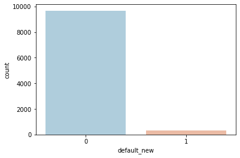

```python
sns.countplot(df['default_new'],palette='RdBu_r')
plt.show()
```

*student* categorical variable represents whether a particular record belongs to a student or not. The below count plot shows distribution of the response *default* with the feature *student*. One conclusion which can be made is that being a student doesn't necessarily mean that a particular record is going to be default on the loan.

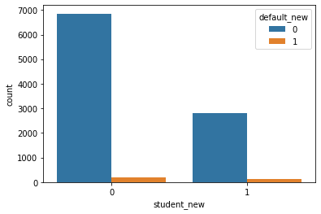

```python
sns.countplot(data=df,x='student_new',hue='default_new')
plt.show()
```

The predicive power of the *Income* continuous feature variable is also not clear from the boxplot below. The Income values overlap between both the values of response, meaning it is almost equally likely for a record to default on loans whehter the income is high or low.

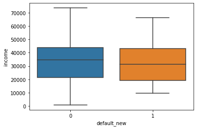

```python
sns.boxplot(data=df,x='default_new',y='income')
plt.show()
```

Finally the *balance* feature provides some class separation. The loan default rates are correlated with the *balance* left on the loan as shown in the boxplot below. The probability of defaulting on a loan increases with the balance amount.

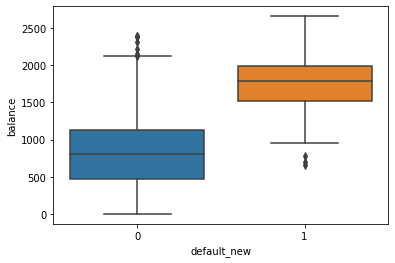

```python
sns.boxplot(data=df,x='default_new',y='balance')
plt.show()
```

Seaborn visualization library has a pairplot function, which is similar to a correlogram. It shows both the distribution and pairwise correlation between the columns in the dataset. The main objective here is to if any of the explanatory variables s strongly correlated with each other or correlated with the response in the form of class bifurcation.

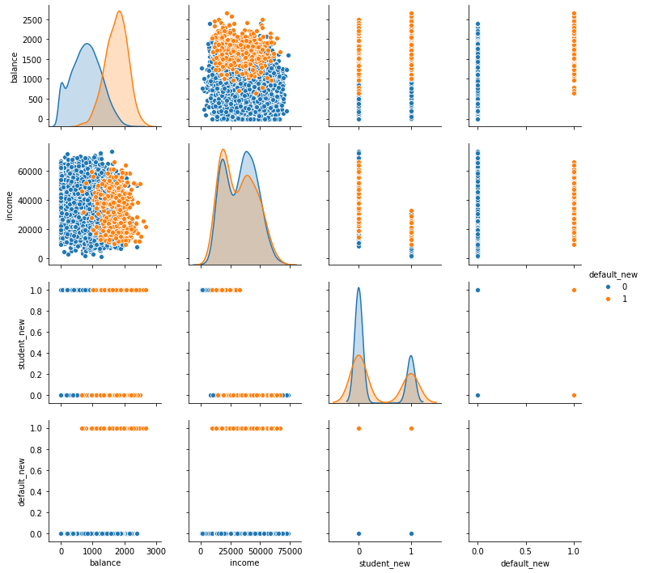

```python
sns.pairplot(df,hue='default_new')
plt.show()
```

### Data Cleanup and conversion to numpy arrays.

```python
df_X = df.drop(labels=['default_new'],axis=1)
df_y = df['default_new']
X = df_X.to_numpy()
y = df['default_new'].to_numpy()
```

### Train Test Split using scikit learn train test split algorithm

Since the response variable sis highly imbalance a stratified train test split was performed so that the training and test sets have the same ratio of *defaults - 1* to *no defaults - 0*

```python
X_train,X_test,y_train,y_test = train_test_split(X,y,test_size=0.3,random_state=101,stratify=y)
y_train = y_train.astype(int)
y_test = y_test.astype(int)
```

The *stratity = y* in the scikit-learn *train_test_split* function makes sure that the ratio of the outcomes are the same in the training and test datasets. Cross validation was not used in this study in order to keep the programming simple.

```python
print("Training Set = ",np.unique(y_train,return_counts=True)[1])
print("Test Set = ",np.unique(y_test,return_counts=True)[1])
```

```
Training Set =  [6767  233]
Test Set =  [2900  100]
```

### Model Fitting

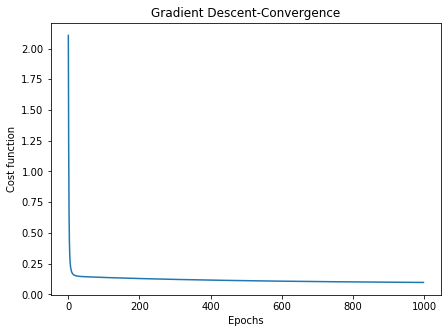

```python
logmodel_gd = logregmodel()
logmodel_gd.fit(X_train,y_train,alpha=1.0,epoch=1000)
logmodel_gd.coefficients_
logmodel_gd.y_pred
plt.figure(figsize=(7,5))
plt.plot(logmodel_gd.cost)
plt.xlabel("Epochs")
plt.ylabel('Cost function')
plt.title("Gradient Descent-Convergence")
plt.show()
```

### Model Accuracy & Confusion matrix

Even though the implemented model is highly accurate based on the below accuracy scores, there are problems with the model's predictive power for the records which *default-1*. Accuracy basically represents overall accuracy and it says that model correctly predicts whether an account will default or not over 96% of the time. Since the classes are highly imbalanced with *default-1* being only fraction of the response variable, this number is highly misleading.

```python
print("Accuracy = ",round(logmodel_gd.scores(X_new=X_test,y_new=y_test),3))
```

```
Accuracy =  0.967
```

The confusion matrix shown below for the test set, clearly shows the model completely misses *default-1* predictions. All the 100 records which defaulted on their loans in the test set are predicted to have not defaulted. (False Positive in the sense that they have not defaulted). This is a big miss by the model and there are no easy fixes here without either changing the cost function or using a different algorithm altogether (gradient boosting for example)

```python
cf = pd.DataFrame(logmodel_gd.confusion_matrix(X_new=X_test,y_new=y_test))
print("Confusion Matrix")
cf
```

```
Confusion Matrix
```

|  | 0 | 1 |
| --- | --- | --- |
| 0 | 2900.0 | 0.0 |
| 1 | 100.0 | 0.0 |

The coefficients of the fit ($\beta$ 's) are shown below which is available as an output.

```python
print(logmodel_gd.coefficients_)
```

```
[[-5.20687936  6.21615569 -1.19264338 -0.43583106]]
```

Finally the *predict* function can predict the class labels and the probability for new input data. A probability of 0.5 is used for the binary class splitting point

```python
y_pred,y_class = logmodel_gd.predict(X_test)
print("Proababilities =",y_pred)
print("Class Label =",y_class)
```

```
Proababilities = [0.04607694 0.07097335 0.00628837 ... 0.05852781 0.03144392 0.07004545]
Class Label = [0. 0. 0. ... 0. 0. 0.]
```

### Comparison with Scikit Learn *LogisticRegression()* model

Scikit learn the popular machine learning library (gold standard) has the Logistic regression model and a comparison is established with the current implementation to further validate it.

```python
logmodel_sklearn = LogisticRegression()
logmodel_sklearn.fit(X_train,y_train)
```

```
LogisticRegression(C=1.0, class_weight=None, dual=False, fit_intercept=True,
                   intercept_scaling=1, l1_ratio=None, max_iter=100,
                   multi_class='warn', n_jobs=None, penalty='l2',
                   random_state=None, solver='warn', tol=0.0001, verbose=0,
                   warm_start=False)
```

The scikit learn model has the same issue as the implemented model with class imbalance. It predicts a high accuracy but completely misses the default rates (*default=1*)

```python
print("Sklearn model Accuracy = ",round(logmodel_sklearn.score(X_test,y_test),3))
```

```
Sklearn model Accuracy =  0.966
```

```python
from sklearn.metrics import confusion_matrix
y_pred = logmodel_sklearn.predict(X_test)
print("Confusion Matrix Scikit Learn")
pd.DataFrame(confusion_matrix(y_test,y_pred))
```

```
Confusion Matrix Scikit Learn
```

|  | 0 | 1 |
| --- | --- | --- |
| 0 | 2899 | 1 |
| 1 | 100 | 0 |

## Conclusion

The logistic regression model was successfully implemented with gradient descent algorithm and just using numpy arrays. The implemented model was compared with scikit-learn's LogisticRegression() function and was found to give essentially he same result. The logistic regression model performs poorly in predicting the loan default rates as the classes are highly imbalanced. The recommendation is to use a slightly modified cost function or use a regularization technique with a penality term to penalize the cost function for predicting defaulted records as not defaulted.